# Pobieranie i przekształcanie surowych wyników egzaminów

Filip Kulon

2015-03-11

# 1 Wymagania

Załadujmy potrzebne pakiety i nawiążmy połączenie z bazą:

```r
library("ZPD")
library("ggplot2")
src = polacz()
```

# 2 Uwagi dotyczące danych

Pobieranie danych z bazy zajmuje dużo czasu. Na potrzeby warsztatów dane zostały pobrane wcześniej i zapisane przy użyciu funkcji `save()` do plików *.RData*. Dzięki temu można je szybko wczytać przy użyciu funkcji `load()`. Polecenia pobierające dane z bazy są poprzedzone znakiem komentarza (#), aby były nieaktywne i nie zostały przez przypadek uruchomione. Zamiast nich aktywne są polecenia wczytujące dane z plików (w takiej formie, jak zwróciłaby je baza).

# 3 Pobieranie wyników surowych

Do pobierania surowych wyników służy funkcja `pobierz_wyniki_egzaminu()`, dla której pomoc można wyświetlić za pomocą polecenia `?pobierz_wyniki_egzaminu`.

Jej składnia jest następująca:  
`pobierz_wyniki_egzaminu(src, rodzajEgzaminu, czescEgzaminu, rokEgzaminu, czyEwd, punktuj = TRUE, idSkali = NULL, skroc = TRUE)`  
argumenty:  
*src* - uchwyt źródła danych dplyr-a  
*rodzajEgzaminu* - rodzaj egzaminu, ktorego wyniki maja zostac pobrane  
*czescEgzaminu* - czesc egzaminu, ktorego wyniki maja zostac pobrane  
*rokEgzaminu* - rok egzaminu, ktorego wyniki maja zostac pobrane  
*czyEwd* - wybor, czy maja byc pobrane wyniki gromadzone przez EWD, czy PAOU  
*punktuj* - wybor, czy dane maja byc pobrane w postaci dystraktorow, czy punktow  
*idSkali* - identyfikator skali, ktora ma zostac zastosowana do danych  
*skroc* - czy do danych zastosowac skrocenia skal opisane w skali

Najkrótsze zastosowanie tej funkcji to `pobierz_wyniki_egzaminu(src, rodzajEgzaminu, czescEgzaminu, rokEgzaminu, czyEwd)` (domyślnie zwraca ona punkty, a nie dystraktory i nie jest stosowana żadna skala).

## 3.1 Ćwiczenie 1

Pobierzmy wyniki z matematyki z egzaminu gimnazjalnego z 2014 roku:

1. Sprawdzamy, jaki to rodzaj i część egzaminu - http://zpd.ibe.edu.pl/doku.php?id=czesci_egzaminu
2. Sprawdzamy, czy będą to *dane EWD* czy *dane PAOU* - http://zpd.ibe.edu.pl/doku.php?id=obazie
3. Pobieramy dane:

   ```r
   # UWAGA! Wykonywanie tego polecenia może zająć kilkanaście minut.
   # gmm14.surowe = pobierz_wyniki_egzaminu(src, "egzamin gimnazjalny", "matematyka", 2014, TRUE) %>% collect()
   load("~/gmm14.surowe.RData")
   head(gmm14.surowe)
   ```

   ```
   ## Source: local data frame [6 x 27]
   ##
   ##   id_obserwacji id_testu id_szkoly  rok k_7424 k_7425 k_7426 k_7427 k_7428
   ## 1      17233868     1596     14040 2014      0      0      0      0      1
   ## 2      17233870     1596     14040 2014      0      1      1      0      0
   ## 3      17233871     1596     14040 2014      1      0      0      1      0
   ## 4       3099719     1596     14040 2014      1      0      1      0      0
   ## 5      17233872     1596     14040 2014      0      0      0      1      1
   ## 6      17233875     1596     14053 2014      1      0      0      0      0
   ## Variables not shown: k_7429 (dbl), k_7430 (dbl), k_7431 (dbl), k_7432
   ##   (dbl), k_7433 (dbl), k_7434 (dbl), k_7435 (dbl), k_7436 (dbl), k_7437
   ##   (dbl), k_7438 (dbl), k_7439 (dbl), k_7440 (dbl), k_7441 (dbl), k_7442
   ##   (dbl), k_7443 (dbl), k_7444 (dbl), k_7445 (dbl), k_7446 (dbl)
   ```

## 3.2 Ćwiczenie 2

Przeprowadźmy jakieś operacje na pobranych danych:

1. Bardzo często interesuje nas wynik ucznia z całego egzaminu, a więc musimy zsumować punktację za wszystkie zadania. Do tego celu służy funkcja `zsumuj_punkty()` (pomoc: `?zsumuj_punkty`).

   Jej składnia jest następująca: `zsumuj_punkty(dane, usunKryteria = TRUE)`  
   argumenty:  
   *dane* - wynik dzialania dowolnej z funkcji `pobierz_wyniki_...()`  
   *usunKryteria* - czy usuwac ze zbioru kolumny z wynikami za poszczegolne kryteria

   UWAGA: Domyślnie (przy podaniu tylko nazwy danych, które chcemy zsumować) funkcja `zsumuj_punkty()` usuwa punktację za poszczególne zadania!
   1. Stwórzmy zmienną zawierającą sumy punktów uczniów z pobranych danych z matematyki:

      ```r
      gmm14.surowe.sumy = zsumuj_punkty(gmm14.surowe)
      head(gmm14.surowe.sumy)
      ```

      ```
      ## Source: local data frame [6 x 5]
      ##
      ##   id_obserwacji id_testu id_szkoly  rok wynik
      ## 1      17233868     1596     14040 2014     4
      ## 2      17233870     1596     14040 2014     5
      ## 3      17233871     1596     14040 2014     4
      ## 4       3099719     1596     14040 2014     8
      ## 5      17233872     1596     14040 2014     6
      ## 6      17233875     1596     14053 2014     8
      ```

   2. Dodajmy zmienną zawierającą sumy punktów uczniów do pobranych danych z matematyki:

      ```r
      gmm14.surowe = zsumuj_punkty(gmm14.surowe, FALSE)
      head(gmm14.surowe)
      ```

      ```
      ## Source: local data frame [6 x 28]
      ##
      ##   id_obserwacji id_testu id_szkoly  rok k_7424 k_7425 k_7426 k_7427 k_7428
      ## 1      17233868     1596     14040 2014      0      0      0      0      1
      ## 2      17233870     1596     14040 2014      0      1      1      0      0
      ## 3      17233871     1596     14040 2014      1      0      0      1      0
      ## 4       3099719     1596     14040 2014      1      0      1      0      0
      ## 5      17233872     1596     14040 2014      0      0      0      1      1
      ## 6      17233875     1596     14053 2014      1      0      0      0      0
      ## Variables not shown: k_7429 (dbl), k_7430 (dbl), k_7431 (dbl), k_7432
      ##   (dbl), k_7433 (dbl), k_7434 (dbl), k_7435 (dbl), k_7436 (dbl), k_7437
      ##   (dbl), k_7438 (dbl), k_7439 (dbl), k_7440 (dbl), k_7441 (dbl), k_7442
      ##   (dbl), k_7443 (dbl), k_7444 (dbl), k_7445 (dbl), k_7446 (dbl), wynik
      ##   (dbl)
      ```

2. Stwórzmy histogram zsumowanych wyników:
   1. za pomocą podstawowej funkcji `hist()`:

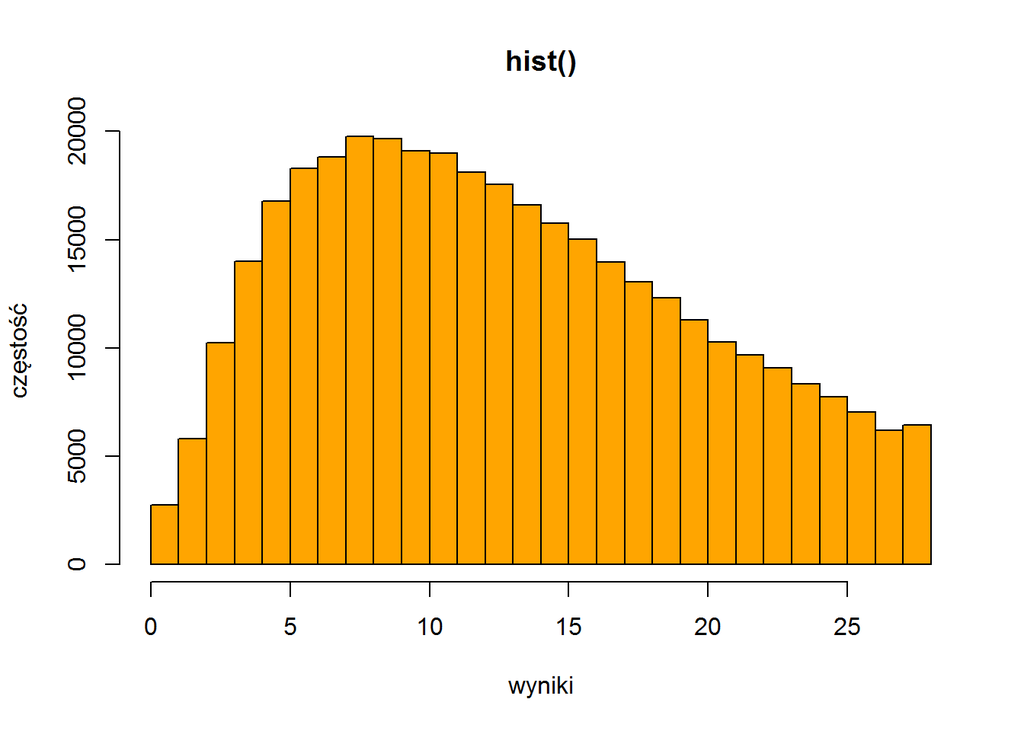

      ```r
      hist(gmm14.surowe.sumy$wynik, col = "orange", main = "hist()", xlab = "wyniki", ylab = "częstość")
      ```

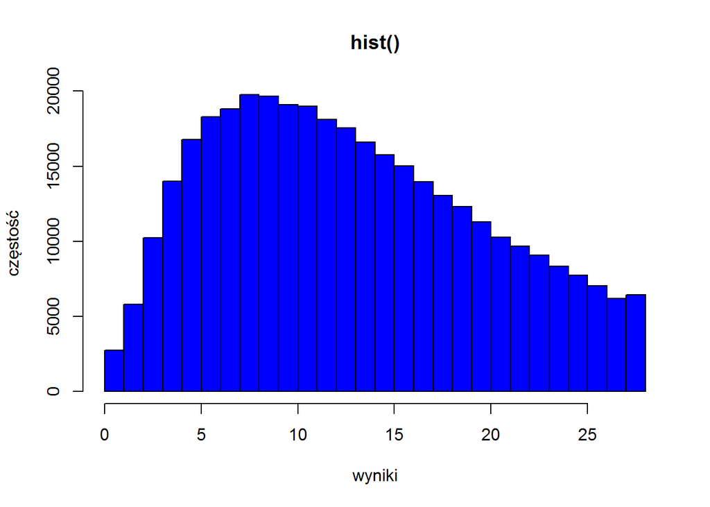

      ```r
      # alternatywnie ze składnią pakietu dplyr konieczne jest wyłuskanie wartości z wybranej kolumny
      gmm14.surowe.sumy %>% select(wynik) %>% .[[1]] %>% hist(col = "blue", main = "hist()", xlab = "wyniki", ylab = "częstość")
      ```

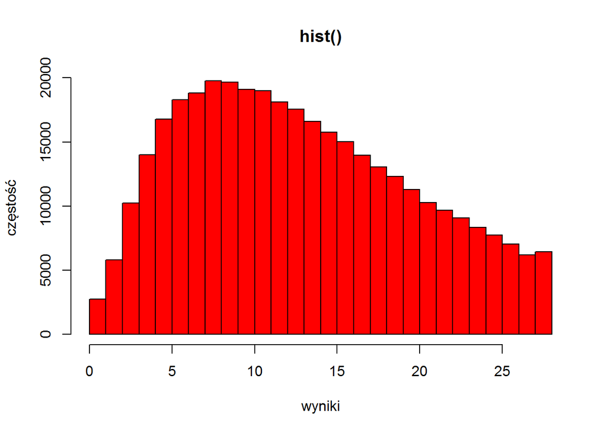

      ```r
      # lub bez użycia funkcji select()
      gmm14.surowe.sumy %>% .[["wynik"]] %>% hist(col = "red", main = "hist()", xlab = "wyniki", ylab = "częstość")
      ```

   2. za pomocą funkcji `qplot()` z biblioteki *ggplot2*:

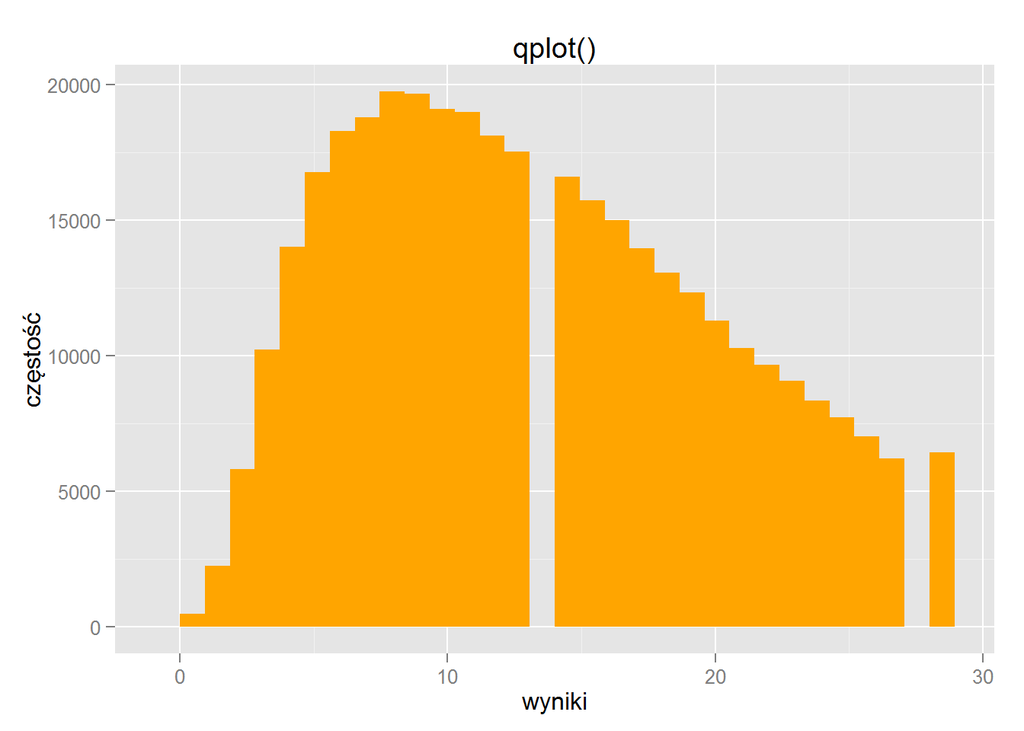

      ```r
      # kolor musimy zdefiniować poprzez funkcję I()
      gmm14.surowe.sumy %>% qplot(wynik, data = ., fill = I("orange"), main = "qplot()", xlab = "wyniki", ylab = "częstość")
      ```

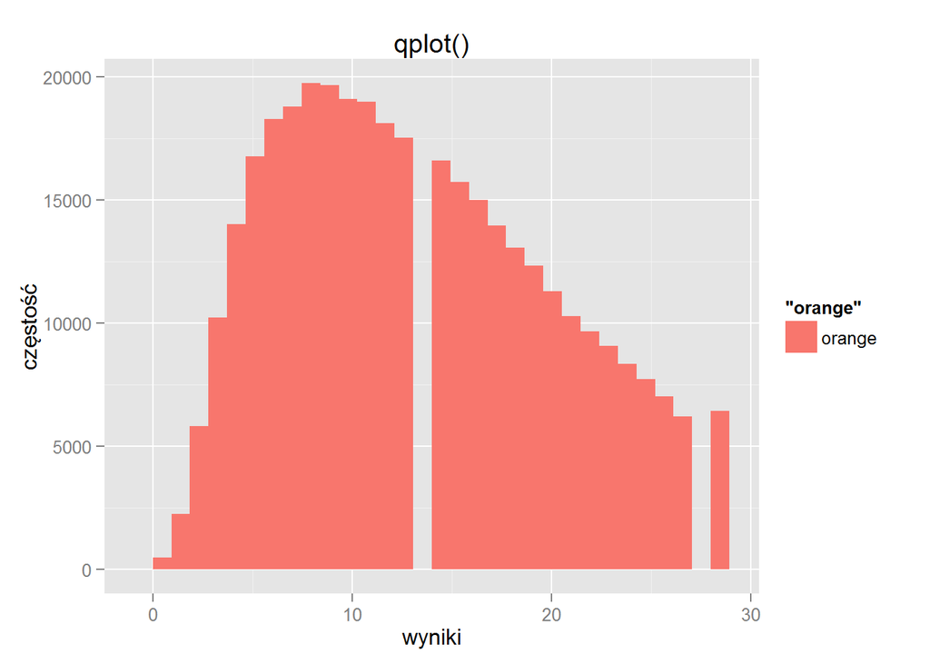

      ```r
      # można porównać z wynikiem bez użycia funkcji I()
      gmm14.surowe.sumy %>% qplot(wynik, data = ., fill = "orange", main = "qplot()", xlab = "wyniki", ylab = "częstość")
      ```

   - Wykresy wyglądają “dziwnie”, otrzymaliśmy informację o parametrze *binwidth* (“koszyku”). Co się stało?
   3. za pomocą funkcji `ggplot()` z biblioteki *ggplot2*:

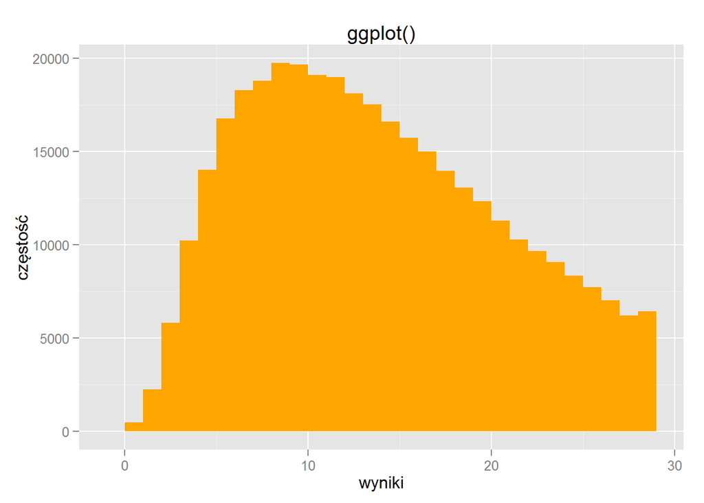

      ```r
      # dodatkowo ustawiamy szerokość "koszyków"
      gmm14.surowe.sumy %>% ggplot(aes(wynik)) + geom_histogram(fill = "orange", binwidth = 1) + ggtitle("ggplot()") + xlab("wyniki") + ylab("częstość")
      ```

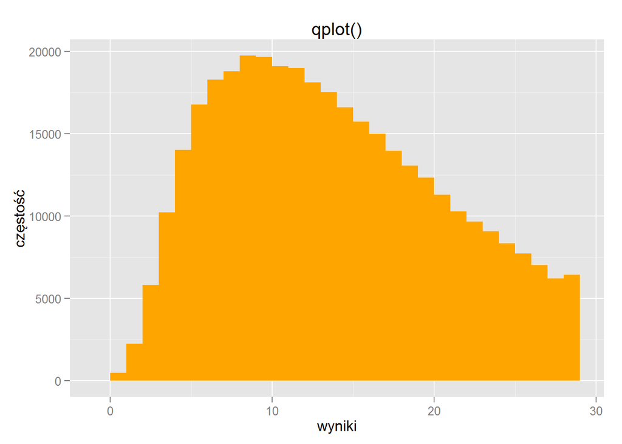

      ```r
      # szerokość "koszyków" można ustawić również w funkcji qplot()
      gmm14.surowe.sumy %>% qplot(wynik, data = ., fill = I("orange"), binwidth = 1, main = "qplot()", xlab = "wyniki", ylab = "częstość")
      ```

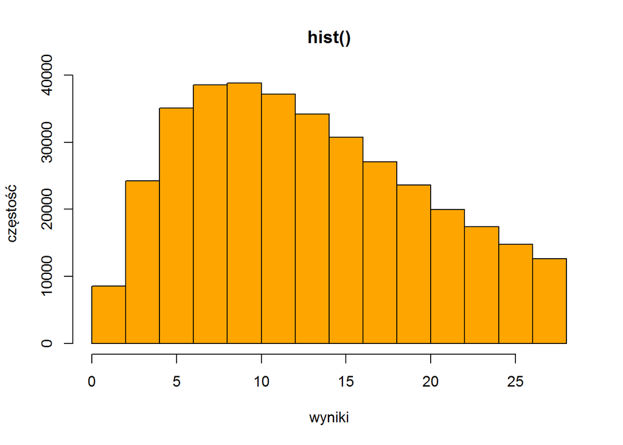

      ```r
      # i funkcji hist()
      hist(gmm14.surowe.sumy$wynik, col = "orange", main = "hist()", xlab = "wyniki", ylab = "częstość", breaks = 10)
      ```

- Czy ma znaczenie, którego obiektu użyjemy: `gmm14.surowe.sumy` czy `gmm14.surowe`?

## 3.3 Ćwiczenie 3

Pobierzmy dystraktory z przyrody z egzaminu gimnazjalnego z 2014 roku:

1. Sprawdzamy, jaki to rodzaj i część egzaminu - http://zpd.ibe.edu.pl/doku.php?id=czesci_egzaminu
   - [ZAAWANSOWANE] możemy to samo uzyskać za pomocą bazy;  
     znajduje się w niej tabela **sl_czesci_egzaminow**, która zawiera potrzebne nam informacje;  
     pobieramy z niej dane i filtrujemy tylko dane dotyczące egzaminu gimnazjalnego:

     ```r
     czesci = tbl(src, "sl_czesci_egzaminow") %>% collect() #pobieramy tabelę z częściami egzaminów
     head(czesci) #wyświetlamy kilka wierszy pobranej tabeli
     ```

     ```
     ## Source: local data frame [6 x 4]
     ##
     ##       rodzaj_egzaminu            czesc_egzaminu prefiks priorytet_id
     ## 1          sprawdzian                                 s           10
     ## 2 egzamin gimnazjalny            historia i WOS    gh_h            1
     ## 3 egzamin gimnazjalny             humanistyczna      gh            2
     ## 4 egzamin gimnazjalny                 j. polski    gh_p            3
     ## 5 egzamin gimnazjalny matematyczno-przyrodnicza      gm            4
     ## 6 egzamin gimnazjalny                matematyka    gm_m            5
     ```

     ```r
     czesci %>% filter(rodzaj_egzaminu == "egzamin gimnazjalny") #filtrujemy tylko części dla egzaminu gimnazjalnego
     ```

     ```
     ## Source: local data frame [7 x 4]
     ##
     ##       rodzaj_egzaminu            czesc_egzaminu prefiks priorytet_id
     ## 1 egzamin gimnazjalny            historia i WOS    gh_h            1
     ## 2 egzamin gimnazjalny             humanistyczna      gh            2
     ## 3 egzamin gimnazjalny                 j. polski    gh_p            3
     ## 4 egzamin gimnazjalny matematyczno-przyrodnicza      gm            4
     ## 5 egzamin gimnazjalny                matematyka    gm_m            5
     ## 6 egzamin gimnazjalny   przedmioty przyrodnicze    gm_p            6
     ## 7 egzamin gimnazjalny  j. angielski rozszerzona  gang_r            7
     ```

2. Sprawdzamy, czy będą to *dane EWD* czy *dane PAOU* - http://zpd.ibe.edu.pl/doku.php?id=obazie
3. Pobieramy dane:

   ```r
   # UWAGA! Wykonywanie tego polecenia może zająć kilkanaście minut!
   # gmp14.surowe.dys = pobierz_wyniki_egzaminu(src, "egzamin gimnazjalny", "przedmioty przyrodnicze", 2014, TRUE, FALSE) %>% collect()
   load("~/gmp14.surowe.dys.RData")
   head(gmp14.surowe.dys)
   ```

   ```
   ## Source: local data frame [6 x 32]
   ##
   ##   id_obserwacji id_testu id_szkoly  rok k_7447 k_7448 k_7449 k_7450 k_7451
   ## 1      17233868     1598     14040 2014      1      2      3      2      1
   ## 2      17233869     1598     14040 2014      4      3      2      1      3
   ## 3       3099719     1598     14040 2014      2      1      2      3      3
   ## 4      17233873     1598     14047 2014      1      1      3      3      3
   ## 5      17233874     1598     14048 2014      1      2      1      3      4
   ## 6       2871030     1598     14049 2014      2      3      1      4      3
   ## Variables not shown: k_7452 (dbl), k_7453 (dbl), k_7454 (dbl), k_7455
   ##   (dbl), k_7456 (dbl), k_7457 (dbl), k_7458 (dbl), k_7459 (dbl), k_7460
   ##   (dbl), k_7461 (dbl), k_7462 (dbl), k_7463 (dbl), k_7464 (dbl), k_7465
   ##   (dbl), k_7466 (dbl), k_7467 (dbl), k_7468 (dbl), k_7469 (dbl), k_7470
   ##   (dbl), k_7471 (dbl), k_7472 (dbl), k_7473 (dbl), k_7474 (dbl)
   ```

## 3.4 Ćwiczenie 4

Wyświetlmy tabelę częstości z wyborami odpowiedzi dla jakiegoś zadania:

1. Sprawdzamy, jaki jest identyfikator zadania, które nas interesuje w wyszukiwarce zadań - http://zpd.ibe.edu.pl/doku.php?id=bazatestypytania
2. Wyświetlmy tabelę częstości dla wybranego zadania:

   ```r
   gmp14.surowe.dys %>% select(k_7447) %>% table()
   ```

   ```
   ## .
   ##     -2     -1      1      2      3      4
   ##     68    445 109902 114274  71648  66412
   ```

- Znaczenie kodów odpowiedzi możemy sprawdzić pod adresem http://zpd.ibe.edu.pl/doku.php?id=obazie
- Czy utworzona tabela jest poprawna?
3. Wyświetlmy tabelę częstości dla wybranego zadania w podziale na wersje testu i tylko poprawne zaznaczenia:

   ```r
   gmp14.surowe.dys %>% select(id_testu, k_7447) %>% filter(k_7447 > 0) %>% table()
   ```

   ```
   ##         k_7447
   ## id_testu     1     2     3     4
   ##     1598 23907 88985 35777 33164
   ##     1599 85995 25289 35871 33248
   ```

- Wersje testu możemy sprawdzić również pod adresem http://zpd.ibe.edu.pl/doku.php?id=bazatestypytania
  - [ZAAWANSOWANE] możemy użyć tylko składni i funkcji biblioteki *dplyr*;  
    oprócz częstości dodatkowo obliczymy procenty:

    ```r
    gmp14.surowe.dys %>% group_by(id_testu, k_7447) %>% filter(k_7447 > 0) %>% summarize(n = n()) %>% mutate(proc = n / sum(n))
    ```

    ```
    ## Source: local data frame [8 x 4]
    ## Groups: id_testu
    ##
    ##   id_testu k_7447     n      proc
    ## 1     1598      1 23907 0.1314778
    ## 2     1598      2 88985 0.4893776
    ## 3     1598      3 35777 0.1967575
    ## 4     1598      4 33164 0.1823871
    ## 5     1599      1 85995 0.4766828
    ## 6     1599      2 25289 0.1401806
    ## 7     1599      3 35871 0.1988382
    ## 8     1599      4 33248 0.1842985
    ```

# 4 Normalizacja ekwikwantylowa

Mając dane ze zsumowanymi punktami możemy dokonać normalizacji ekwikwantylowej.

W tym celu korzystamy z funkcji `normalizuj_ekwikwantylowo()` (pomoc: `?normalizuj_ekwikwantylowo`). Jej składnia jest następująca: `normalizuj_ekwikwantylowo(dane, src = NULL, kolWynik = "wynik", idSkali = NULL, ...)`  
argumenty:  
*dane* - ramka danych zawierająca wyniki  
*src* - uchwyt źródła danych dplyr-a (gdy normalizacja na podstawie norm w bazie)  
*kolWynik* - nazwa kolumny zawierającej wyniki  
*idSkali* - skala, której norma z bazy ma zostać zastosowana  
*…* - ew. parametry funkcji normy_ekwikwantylowe() (gdy normalizacja na podstawie danych)

Dostępne są dwie metody:

- z normami wyliczanymi na podstawie danych (domyślnie),
- z normami wczytanymi z bazy (wyliczonymi na potrzeby *Kalkulatora EWD*).

## 4.1 Ćwiczenie 5

Wyliczmy normy z danych:

```r
gmm14.surowe.sumy = normalizuj_ekwikwantylowo(gmm14.surowe.sumy)
head(gmm14.surowe.sumy)
```

```
##   id_obserwacji id_testu id_szkoly  rok wynik wynik_norm
## 1      17233868     1596     14040 2014     4   77.78839
## 2      17233870     1596     14040 2014     5   81.72182
## 3      17233871     1596     14040 2014     4   77.78839
## 4       3099719     1596     14040 2014     8   90.55820
## 5      17233872     1596     14040 2014     6   85.07199
## 6      17233875     1596     14053 2014     8   90.55820
```

## 4.2 Ćwiczenie 6

Wyliczmy normy z Kalkulatora EWD.

Zastosowanie norm z Kalkulatora EWD wymaga zastosowania *skali*. *Skala* opisuje przekształcenia danych takiej jak sumowanie kryteriów oceny czy skracanie skal punktowych. Musimy zatem:

1. Znaleźć stosowną skalę za pomocą funkcji `pobierz_skale()`.
2. Znormalizować wyniki.

```r
# 1. wyszukujemy skalę
pobierz_skale(src) %>%
  filter(normy_ekwikwantylowe == TRUE, rodzaj_egzaminu == "egzamin gimnazjalny", czesc_egzaminu == "matematyka", rok == 2014)
```

```
## Source: postgres 9.4.1 [ewd_baza@ewd.ibe.edu.pl:5432/ewd]
## From: <derived table> [?? x 17]
## Filter: normy_ekwikwantylowe == TRUE, rodzaj_egzaminu == "egzamin
##   gimnazjalny", czesc_egzaminu == "matematyka", rok == 2014
##
##    id_skali opis_skali   nazwa_skali rodzaj_skali skala_do_prezentacji
## 1       723            ewd;gm_m;2014          ewd                 TRUE
## 2       722              ewd;gm;2014          ewd                 TRUE
## 3       723            ewd;gm_m;2014          ewd                 TRUE
## 4       722              ewd;gm;2014          ewd                 TRUE
## ..      ...        ...           ...          ...                  ...
## Variables not shown: rodzaj_egzaminu (chr), czesc_egzaminu (chr), id_testu
##   (int), rok (dbl), skalowanie (int), opis_skalowania (chr), estymacja
##   (chr), data_skalowania (date), skalowanie_do_prezentacji (lgl),
##   normy_ekwikwantylowe (lgl), posiada_eap (lgl), posiada_pv (lgl)
```

Spośród wyświetlonych skal nas interesuje skala 723 (dotyczy tylko części *gm_m* - patrz kolumna *nazwa_skali*)

```r
# 2. normalizujemy (dodatkowo zmieniając nazwę poprzedniej normalizacji, żeby móc porównać wyniki)
gmm14.surowe.sumy = gmm14.surowe.sumy %>% rename(wynik_norm_dane = wynik_norm) %>% normalizuj_ekwikwantylowo(src, idSkali = 723)
head(gmm14.surowe.sumy)
```

```
##   id_obserwacji id_testu id_szkoly  rok wynik wynik_norm_dane wynik_norm
## 1      17233868     1596     14040 2014     4        77.78839    77.0822
## 2      17233870     1596     14040 2014     5        81.72182    81.0142
## 3      17233871     1596     14040 2014     4        77.78839    77.0822
## 4       3099719     1596     14040 2014     8        90.55820    89.9473
## 5      17233872     1596     14040 2014     6        85.07199    84.3891
## 6      17233875     1596     14053 2014     8        90.55820    89.9473
```

Porównajmy wyniki przed i po normalizacji:

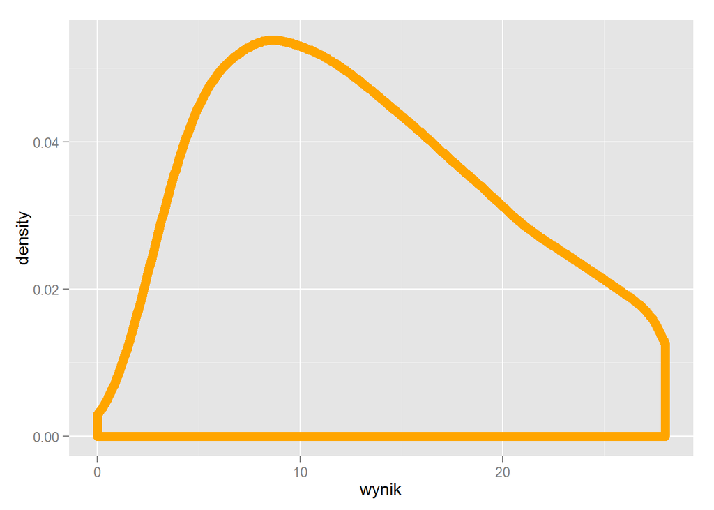

```r
# wyniki surowe
gmm14.surowe.sumy %>% ggplot(aes(wynik)) +
  geom_density(color = "orange", size = 3, adjust = 2)
```

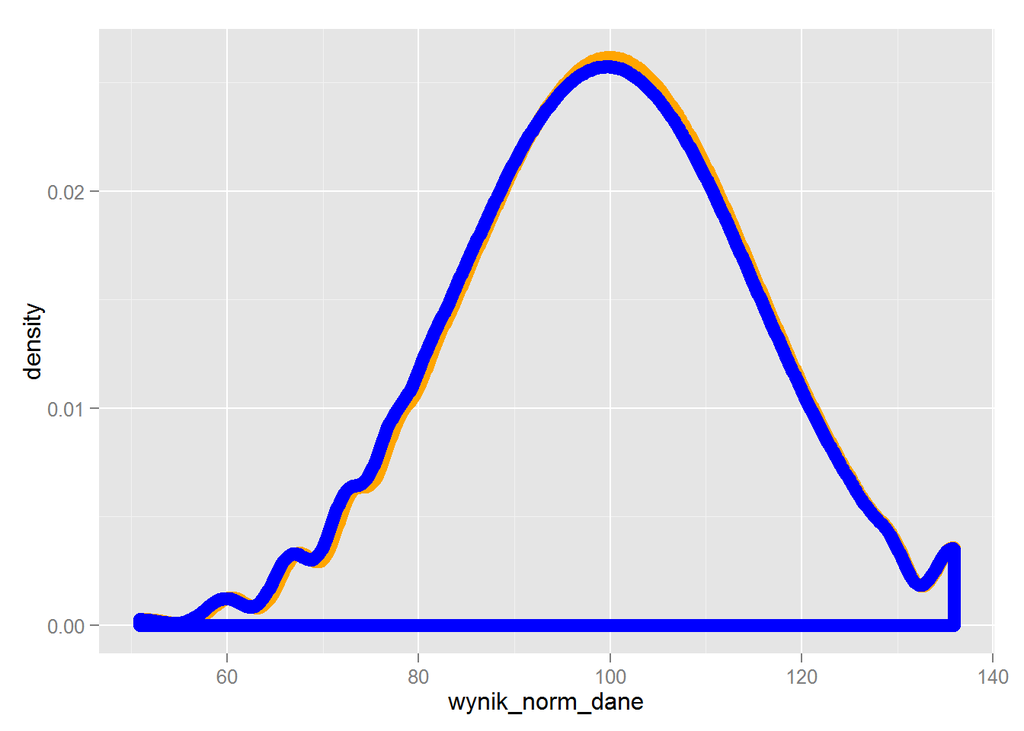

```r
# porównanie wyników znormalizowanych
gmm14.surowe.sumy %>% ggplot() +
  geom_density(aes(wynik_norm_dane), color = "orange", size = 3, adjust = 2) +
  geom_density(aes(wynik_norm), color = "blue", size = 3, adjust = 2)
```

# 5 Pomijanie uczniów przystępujących wielokrotnie do egzaminu

Czasami (w wypadku EWD na ogół) interesować mogą nas tylko uczniowie piszący dany egzamin po raz pierwszy (na wyjściu) lub ostatni (na wejściu).

Do ich odfiltrowywania służy funkcja `filtruj_przystapienia()` (pomoc: `?filtruj_przystapienia`). Dla wskazanego *rodzaju egzaminu* (lub tylko dla wybranej *części egzaminu*) oraz określenia z jakiego źródła (EWD/PAOU) mają pochodzić dane, zwraca ona zbiór zawierający jedynie pierwsze lub ostatnie przystąpienia uczniów do danego egzaminu.

Jej składnia jest następująca:  
`filtruj_przystapienia(src, pierwsze, rodzajEgzaminu, czescEgzaminu = NULL, czyEwd, obserwacje = NULL)`  
argumenty:  
*src* - uchwyt źródła danych dplyr-a  
*pierwsze* - czy odfiltrować pierwsze podejście (jeśli FALSE, odfiltrowane zostanie ostatnie)  
*rodzajEgzaminu* - rodzaj egzaminu - patrz http://zpd.ibe.edu.pl/doku.php?id=czesci_egzaminu  
*czescEgzaminu* - wektor części egzaminu - patrz http://zpd.ibe.edu.pl/doku.php?id=czesci_egzaminu  
*czyEwd* - czy korzystać z danych EWD czy PAOU (patrz opis)  
*obserwacje* - wektor id_obserwacji lub ramka danych z kolumną id_obserwacji

Za pomocą złączenia *inner_join* lub filtrowania *semi_join* można odfiltrować pożądane wyniki egzaminu lub oszacowania umiejętności uczniów.

Złączmy przygotowane powyżej sumy punktów z informacjami o pierwszym przystąpieniu do egzaminu gimnazjalnego: * sprawdzając przystąpienia tylko w obrębie części egzaminu *matematyka*, * sprawdzając przystąpienia w obrębie całego egzaminu gimnazjalnego.

W obydwu wypadkach dla *danych EWD*, bo właśnie na takich danych mamy policzone sumy punktów.

```r
# UWAGA! Wykonywanie tych poleceń może zająć kilka minut.
# filtrMat = filtruj_przystapienia(src, TRUE, "egzamin gimnazjalny", "matematyka", TRUE) %>% collect()
# filtrGim = filtruj_przystapienia(src, TRUE, "egzamin gimnazjalny", NULL, TRUE) %>% collect()
load("~/filtry.RData")
head(filtrMat)
```

```
## Source: local data frame [6 x 5]
##
##   id_obserwacji dane_ewd     rodzaj_egzaminu czesc_egzaminu  rok
## 1      16035244     TRUE egzamin gimnazjalny     matematyka 2014
## 2      15947372     TRUE egzamin gimnazjalny     matematyka 2014
## 3      15785410     TRUE egzamin gimnazjalny     matematyka 2014
## 4       2949104     TRUE egzamin gimnazjalny     matematyka 2012
## 5       3079171     TRUE egzamin gimnazjalny     matematyka 2012
## 6       3322878     TRUE egzamin gimnazjalny     matematyka 2013
```

```r
head(filtrGim)
```

```
## Source: local data frame [6 x 4]
##
##   id_obserwacji dane_ewd     rodzaj_egzaminu  rok
## 1       3316818     TRUE egzamin gimnazjalny 2013
## 2       3375654     TRUE egzamin gimnazjalny 2013
## 3       1297632     TRUE egzamin gimnazjalny 2008
## 4       3090901     TRUE egzamin gimnazjalny 2012
## 5       2344626     TRUE egzamin gimnazjalny 2011
## 6       2808201     TRUE egzamin gimnazjalny 2012
```

```r
# filtrujemy
gmm14.filtrMat = gmm14.surowe.sumy %>% inner_join(filtrMat)
gmm14.filtrGim = gmm14.surowe.sumy %>% inner_join(filtrGim)
# jaka jest różnica w liczbie obserwacji?
nrow(gmm14.filtrMat) - nrow(gmm14.filtrGim)
```

```
## [1] 128
```

- Z czego wynika różnica w liczbie obserwacji pomiędzy jednym i drugim sposobem filtrowania?

# 6 Złączanie danych pomiędzy egzaminami

Na wstępie warto zaznaczyć, że **nie wszystkie wyniki egzaminacyjne i oszacowania umiejętności uczniów są łączliwe między latami**. Szczegółowe informacje znajdują się pod adresem http://zpd.ibe.edu.pl/doku.php?id=obazie

Złączanie następuje wprost po *id_obserwacji*, więc co najwyżej dane się nie połączą.

Warto jeszcze zauważyć, że złączane zbiory mogą zawierać jednakowo nazywające się kolumny (np. *wynik*, *dysleksja*, itp.), które przed złączeniem należy zmienić im nazwy (np. na *wynik_spr*, *wynik_gh*, *dysleksja_spr*, *dysleksja_gh* itd.).

Przyłączmy do policzonych sum surowych punktów z egzaminu GMM 2014 wyniki sprawdzianu 2011. W tym celu musimy: 1. Pobrać wyniki sprawdzianu 2011 z danych EWD (dodatkowo policzymy sumę punktów).

```r
# UWAGA! Wykonywanie tego polecenia może zająć kilkanaście minut!
# spr11 = pobierz_wyniki_egzaminu(src, "sprawdzian", "", 2011, TRUE) %>% collect()
load("~/spr11.RData")
spr11 = zsumuj_punkty(spr11)
head(spr11)
```

```
## Source: local data frame [6 x 5]
##
##   id_obserwacji id_testu id_szkoly  rok wynik
## 1      15873799      645     32723 2011    19
## 2      15873782      645     32723 2011    23
## 3      15873788      645     32723 2011    24
## 4      15873786      645     32723 2011    17
## 5      15873793      645     32723 2011    29
## 6      15873780      645     32723 2011    31
```

2. Zmienić nazwy kolumn.

```r
spr11 = spr11 %>% rename(wynik_spr = wynik, rok_spr = rok, id_testu_spr = id_testu, id_szkoly_spr = id_szkoly)
head(spr11)
```

```
## Source: local data frame [6 x 5]
##
##   id_obserwacji id_testu_spr id_szkoly_spr rok_spr wynik_spr
## 1      15873799          645         32723    2011        19
## 2      15873782          645         32723    2011        23
## 3      15873788          645         32723    2011        24
## 4      15873786          645         32723    2011        17
## 5      15873793          645         32723    2011        29
## 6      15873780          645         32723    2011        31
```

3. Połączyć wyniki z obydwu egzaminów.

```r
polaczone = gmm14.surowe.sumy %>% left_join(spr11)
head(polaczone)
```

```
##   id_obserwacji id_testu id_szkoly  rok wynik wynik_norm_dane wynik_norm
## 1      17233868     1596     14040 2014     4        77.78839    77.0822
## 2      17233870     1596     14040 2014     5        81.72182    81.0142
## 3      17233871     1596     14040 2014     4        77.78839    77.0822
## 4       3099719     1596     14040 2014     8        90.55820    89.9473
## 5      17233872     1596     14040 2014     6        85.07199    84.3891
## 6      17233875     1596     14053 2014     8        90.55820    89.9473
##   id_testu_spr id_szkoly_spr rok_spr wynik_spr
## 1           NA            NA      NA        NA
## 2           NA            NA      NA        NA
## 3           NA            NA      NA        NA
## 4           NA            NA      NA        NA
## 5           NA            NA      NA        NA
## 6           NA            NA      NA        NA
```

Możemy sprawdzić, dla ilu uczniów połączyliśmy wyniki.

```r
polaczone %>%
  group_by(is.na(rok_spr)) %>%
  summarize(n = n())
```

```
## Source: local data frame [2 x 2]
##
##   is.na(rok_spr)      n
## 1          FALSE 335154
## 2           TRUE  27595
```

Jak widać nie przyłączyło się nieco ponad 27 tys. uczniów (np. o opóźnionym toku kształcenia).

## 6.1 Ćwiczenie 7

Zróbmy wykres rozrzutu dla wyników obydwu egzaminów.

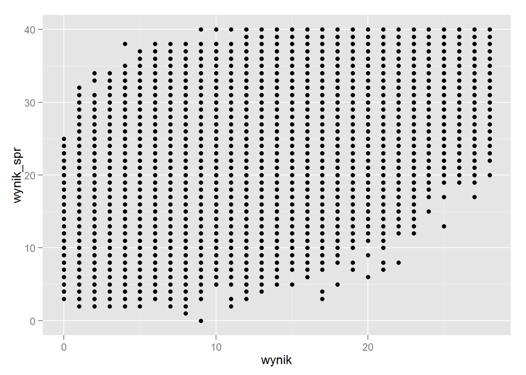

```r
#geom_point() utworzy wykres rozrzutu
polaczone %>% ggplot(aes(wynik, wynik_spr)) + geom_point()
```

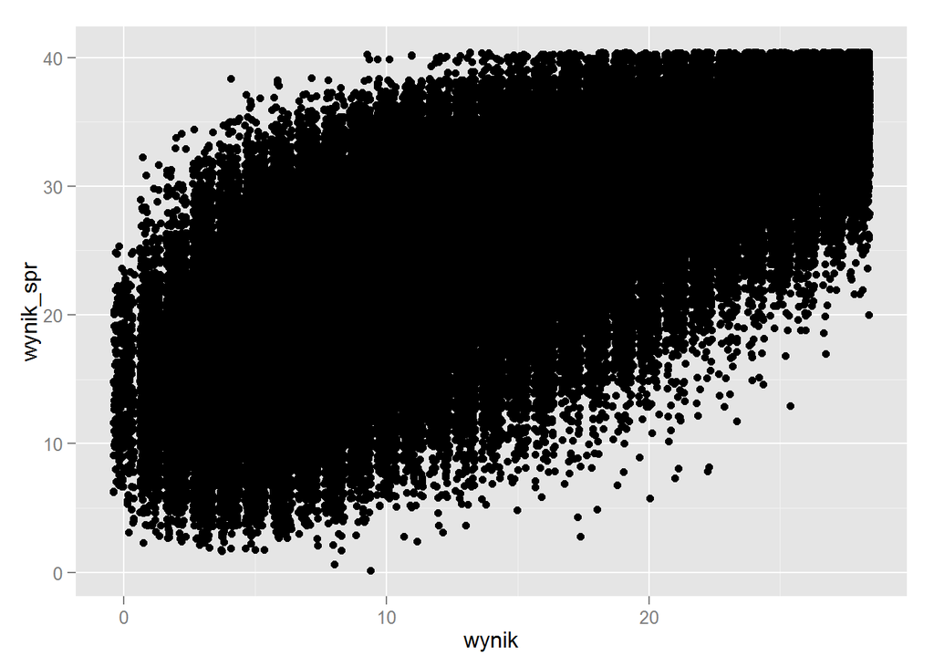

```r
#geom_jitter() doda nieco "szumu" do danych
polaczone %>% ggplot(aes(wynik, wynik_spr)) + geom_jitter()
```